# Evaluation des hypothèses de base du Chapitre 1 sur les données transactionnelles Decentraland sur Opensea

## Lien Localisation - Attention - Liquidité

### Construction de la base de données

Nous allons régresser la liquidité sur l’attention et la localisation. Pour cela, nous avons besoin de construire pour chaque vente, les mesures d’attention à la date de la vente. Nous partirons sur trois mesures d’attention:

```r
# Construction of "Liquidity - Attention - Localisation" Database
lal_sales <- ListingSales |> # Sales database
  filter(type == "sale" & !is.na(ref_shared_id)) |> # Select sales related to listings
  mutate(
    filter_date_start = lubridate::floor_date(date - days(30), unit = "day"), # Create 30 previous-day window (Window Start)
    filter_date_end = lubridate::floor_date(date, unit = "day") # Create 30 previous-day window (Window End)
  ) |>
  rename(
    sale_date = date # Rename sale date variable (to prevent ambiguity when we will join sales database with Bids database)
  ) |>
  select( # Select only important variables
    asset_id, # Parcel ID
    sale_date,# Sale date
    ref_ttf,  # Time on market
    filter_date_start, # 30 previous-day window start
    filter_date_end # 30 previous-day window end
  ) |>
  left_join( # Join sales database with bids (attention) database
    FilteredBids |>
      select(asset_id, date, bidder) |> # Select only important variable in attention database
      rename( # Rename columns for join
        bid_date = date, # Attention date
        bid_asset_id = asset_id # Parcel ID
      ),
    by = join_by(
      asset_id == bid_asset_id, # Join on Parcel ID
      filter_date_start <= bid_date, # Join also when attention date is in 30 previous-day (sales) window
      filter_date_end > bid_date
    )
  ) |>
  group_by(asset_id, sale_date, bidder) |> # Group by parcel id, sale date, bidder
  summarise(
    ref_ttf = first(ref_ttf),  # Get time on market
    n_bids_30d = sum(!is.na(bid_date)) # Count number of bids placed by `bidder` on `parcel_id` in the 30 previous-day window preceding sale date
  ) |>
  ungroup() |> # Relax group
  group_by(asset_id, sale_date) |> # Group by parcel id, sale date
  summarise(
    ref_ttf = first(ref_ttf), # Get time on market
    n_bidders_30d = sum(n_bids_30d > 0), # Count total number of unique bidders on `parcel_id` in the 30 previous-day window preceding sale date
    n_bids_30d = sum(n_bids_30d), # Count total number of bids placed on `parcel_id` in the 30 previous-day window preceding sale date
    .groups = "drop"
  ) |>
  mutate(
    is_bidden_30d = factor(as.numeric(n_bids_30d > 0), levels = c("0", "1"), labels = c("NO", "YES")) # Dummy variable (is 1 if a bid was placed on parcel_id in 30 previous-day window preceding sale date, 0 otherwise)
  ) |>
  ungroup() |> # Relax group
  rename(
    tom = ref_ttf, # Good name for time on variable
    date = sale_date # Good name for sale date
  ) |>
  left_join( # Join with Locations database
    Locations |>
      select( # Take only some columns in locations database
        TOKEN_ID, TYPE, DIST_PLAZA_central, DIST_NRS_PLAZA, NAME_NRS_PLAZA, DIST_ROAD,
        DIST_NRS_DISTRICT_CAT, NAME_NRS_DISTRICT_CAT
      ) |>
      mutate(
        IN_DISTRICT = as.numeric(TYPE == "district") # Infer is parcel is in a district or not
      ) |>
      rename(
        asset_id = TOKEN_ID, # Parcel_id
        IDX = IN_DISTRICT, # Parcel is in district ?
        DPC = DIST_PLAZA_central, # Distance to central plaza
        DPX = DIST_NRS_PLAZA, # Distance to neareat peripheral plaza
        NPX = NAME_NRS_PLAZA, # Name of nearest peripheral plaza
        DRD = DIST_ROAD, # Distance to road
        DDX = DIST_NRS_DISTRICT_CAT, # Distance to nearest district
        NDX = NAME_NRS_DISTRICT_CAT # Category of nearest ditrict
      ) |>
      select(-TYPE),
    by = "asset_id"
  )
```

```r
str(lal_sales)
```

```
tibble [5,210 × 13] (S3: tbl_df/tbl/data.frame)
 $ asset_id     : chr [1:5210] "100" "101" "102" "10208471007628153903901238222953046343532" ...
 $ date         : POSIXct[1:5210], format: "2026-02-06 09:49:35" "2026-02-06 09:49:35" "2026-02-06 10:03:35" "2025-03-05 11:54:23" ...
 $ tom          : chr [1:5210] "0.034051" "0.034051" "0.043773" "0.412882" ...
 $ n_bidders_30d: int [1:5210] 0 0 0 0 0 0 0 0 0 0 ...
 $ n_bids_30d   : int [1:5210] 0 0 0 0 0 0 0 0 0 0 ...
 $ is_bidden_30d: Factor w/ 2 levels "NO","YES": 1 1 1 1 1 1 1 1 1 1 ...
 $ DPC          : num [1:5210] 91 92 93 140 140 ...
 $ DPX          : num [1:5210] 8 9 10 60.1 60.1 ...
 $ NPX          : chr [1:5210] "north" "north" "north" "south" ...
 $ DRD          : num [1:5210] 6 7 8 2 2 3 3 1 2 2 ...
 $ DDX          : num [1:5210] 0 0 0 46.1 46.1 ...
 $ NDX          : chr [1:5210] "art" "art" "art" "game" ...
 $ IDX          : num [1:5210] 1 1 1 0 0 0 0 0 1 1 ...
```

### Régressions

#### Liquidité en fonction de l’attention

Nous régressons la liquidité sur les mesures d’attention.

```r
# Explained variable: `tom` = Time On Market
# Regressors:
# - `is_bidden_30d`: Is There a bid placed on the parcel in the 30 previous days preceding sale date ?

res = lm_model(
  lal_sales,
  Y = c("tom"),
  X = c("is_bidden_30d")
)
summary(res$model)
```

**De manière contre-intuitive**, si la parcelle a été demandée dans les 30 jours précédant la date de la vente, alors **son temps sur le marché est augmenté**.

```r
# Explained variable: `tom` = Time On Market
# Regressors:
# - `n_bidders_30d`: Number of unique bidders on the parcel in the 30 previous days preceding sale date

res = lm_model(
  lal_sales,
  Y = c("tom"),
  X = c("n_bidders_30d")
)
summary(res$model)
```

**De manière contre-intuitive**, plus l’attention suscitée autour de la parcelle (mesurée par le nombre de demandeurs distincts de la parcelle dans les 30 jours précédant la date de la vente) est grande, **plus son temps sur le marché est grand**.

#### Liquidité en fonction de l’attention et de la localisation

Nous régressons la liquidité sur la localisation et les mesures d’attention.

```r
# Explained variable: `tom` = Time On Market
# Regressors:
# - `is_bidden_30d`: Is There a bid placed on the parcel in the 30 previous days preceding sale date ?
# - `DPC`: Distance to Central Plaza
# - `DPX`: Distance to closest Peripheral Plaza
# - `NPX`: Name of Peripheral Plaza (north, south, east, west, north-east, south-east, north-west, south-west)
# - `DRD`: Distance to Road
# - `DDX`: Distance to closest District
# - `IDX`: Is Parcel a District Parcel ?

res = lm_model(
  lal_sales,
  Y = c("tom"),
  X = c("is_bidden_30d", "DPC", "DPX", "DRD", "NPX", "IDX")
)
summary(res$model)
```

L’effet de l’attention (mesurée par l’existence d’un bid sur la parcelle dans les 30 jours précédant la vente) sur la liquidité est le même que précédemment. De plus, les effets de la localisation sont maintenus en présence de l’attention.

```r
# Explained variable: `tom` = Time On Market
# Regressors:
# - `n_bidders_30d`: Number of unique bidders on the parcel in the 30 previous days preceding sale date
# - `DPC`: Distance to Central Plaza
# - `DPX`: Distance to closest Peripheral Plaza
# - `NPX`: Name of Peripheral Plaza (north, south, east, west, north-east, south-east, north-west, south-west)
# - `DRD`: Distance to Road
# - `DDX`: Distance to closest District
# - `IDX`: Is Parcel a District Parcel ?

res = lm_model(
  lal_sales,
  Y = c("tom"),
  X = c("n_bidders_30d", "DPC", "DPX", "DRD", "NPX", "IDX")
)
summary(res$model)
```

L’effet de l’attention (mesurée par le nombre de demandeurs distincts de la parcelle dans les 30 jours précédant la date de la vente) sur la liquidité est le même que précédemment. De plus, les effets de la localisation sont maintenus en présence de l’attention.

### Conclusion

Il semblerait que l’attention déprécie la liquidité de la parcelle. Une explication possible pourrait être la suivante: plus l’attention (mesurée par la demande) sur la parcelle est forte, plus le détenteur de la parcelle met du temps à se décider à accepter une réponse reçue à l’offre spontanée (et donc à boucler la vente). A contrario, le détenteur d’une parcelle non demandée (qui n’a pas fait l’objet d’attention) accepte rapidement une réponse à l’offre spontanée, certainement par FOMO (Fear Of Missing Out).

En outre, il se peut que la mesure utilisée pour l’attention soit ontologiquement de nature à provoquer l’effet observé. En effet, demande et offre sont liées. Comme dit précédemment, le détenteur d’une parcelle demandée peut se permettre de ne pas boucler rapidement une vente car se disant que les acheteurs ne manqueront pas, tandis que le détenteur d’une parcelle non demandée veut rapidement conclure, au risque de laisser partir l’acheteur.

Pour tirer parti de la demande comme mesure d’attention, il serait peut-être intéressant d’exclure de l’analyse les parcelles non demandées, et mesurer la différence de liquidité entre les parcelles faiblement demandées (2-3 demandeurs uniques) et fortement demandées (plus de 3 demandeurs uniques). Peut-être que l’effet observé subsistera, auquel cas faudra-t’il soit réfléchir sur une autre mesure de l’attention, soit partir sur une base de données moins problématique.

En effet, la base de données utilisée dans cet exercice, dont la source est Opensea, ne fournit des données qu’à partir de septembre 2024 jusqu’à nos jours. Cette période est une période morte, dont l’activité transactionnelle est faible et potentiellement non représentative de la dynamique sur la totalité de la durée de vie des métavers decentralisés, depuis 2020. De plus, les demandes spontannées issues de Opensea sont énormément bruitées car polluées par l’activité des bots. Nous avons certes opéré un filtrage, mais aucun test formel de celui n’a été fait pour s’assurer que le filtrage n’est ni trop exclusif ni trop permissif.

La marketplace officielle de Decentraland, offre la possibilité d’obtenir les données des listings, bids et ventes de parcelles à partir de la blockchain. Toutes les opérations issus de cette marketplace sont écrites dans la blockchain, ce qui rend impossible la pollution des bids par les bots car placer des milliers de bids deviendrait couteux en frais de transactions blockchain. De plus, la marketplace officielle de Decentraland est la première place de marché utilisée par les habitants du métavers pour s’échanger les biens de l’univers virtuel. Les autres marketplace (Opensea / Rarible) sont plus utilisés par les personnes qui fréquentent très peu voire pas du tout le métavers, et essentiellement (je présume ici) à des fins spéculatives car Opensea et Rarible sont les deux marketplace NFT (plus généralement) les plus gros.

## NEXT STEPS 20/05/2026

- **Exclure les parcelles non demandées dans l’analyse précédente**
- **Télécharger les données Decentraland Marketplace**
- **Télécharger les historiques de modification de parcelles** et les utiliser comme proxy de l’attention: **Plus une parcelle fait l’objet de modifications, plus son détenteur l’utilise et l’exploite, et donc on suppose que c’est parce qu’il y a intérêt, et donc plus elle attire l’attention des visiteurs** Bien que Kawai et al. montrent que les parcelles les plus modifiées sont les moins listées, on pourrait inclure dans cet analyse une composante spatiale (pour une parcelle vendue, attention = nombre de parcelles modifiées dans un périmètre précis, sur 30 derniers jours).

## Exclusion des parcelles non demandées

Nous allons exclure des analyses précédentes les parcelles qui n’ont pas été demandées. Ainsi, nous nous focalisation sur l’attention portée sur les parcelles demandées. Nous créons une variable binaire à partir du nombre de demandeurs uniques d’une parcelle, qui vaut:

- 0 si le nombre de demandeurs uniques est inférieur ou égal à un seuil fixé (exemple 1 ou 2). Cela signifie que l’attention portée sur cette parcelle est faible.
- 1 si le nombre de demandeurs uniques est supérieur au seuil précédent. Cela signifie que l’attention portée sur la parcelle est forte.

### Lien Localisation - Attention

A faire…

### Lien Localisation - Attention - Liquidité

#### Base de données

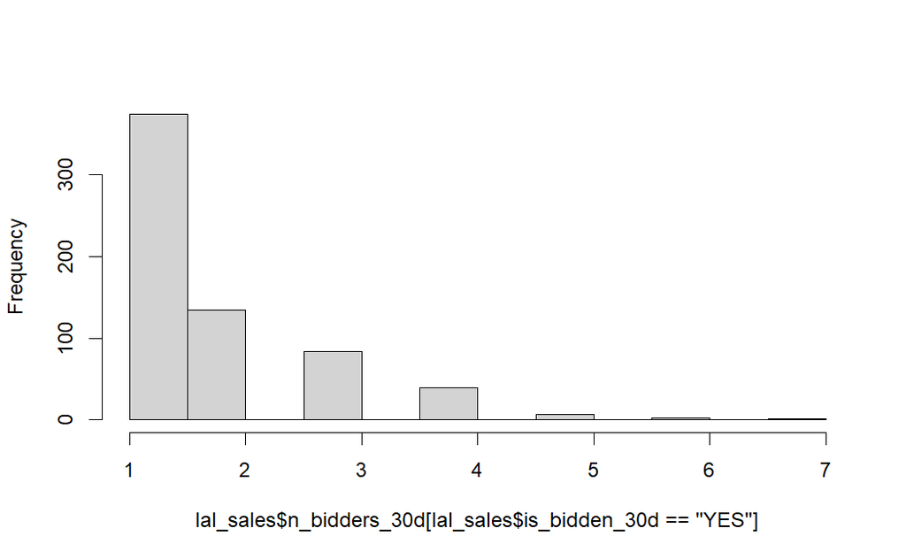

```r
hist(lal_sales$n_bidders_30d[lal_sales$is_bidden_30d == "YES"], main = NULL)
```

```r
lal_sales2 <- lal_sales |>
  filter(is_bidden_30d == "YES") |>
  mutate(
    attention = factor(as.numeric(n_bidders_30d > 2), levels = c("0", "1"), labels = c("WEAK", "STRONG"))
  )
```

#### Liquidité en fonction de l’attention

Nous régressons la liquidité sur les mesures d’attention.

```r
# Explained variable: `tom` = Time On Market
# Regressors:
# - `attention`: Is Attention on parcel in the 30 previous days Weak or Strong (Based on N_bidders <= 1 or not) ?

res = lm_model(
  lal_sales2,
  Y = c("tom"),
  X = c("attention")
)
summary(res$model)
```

```
Call:
lm(formula = fml, data = dataset, x = T, y = T)

Residuals:
   Min     1Q Median     3Q    Max
-5.021 -2.461 -1.823  0.601 90.167

Coefficients:
                Estimate Std. Error t value Pr(>|t|)
(Intercept)       2.5603     0.2781   9.208  < 2e-16 ***
attentionSTRONG   2.4616     0.6051   4.068 5.32e-05 ***
---
Signif. codes:  0 ‘***’ 0.001 ‘**’ 0.01 ‘*’ 0.05 ‘.’ 0.1 ‘ ’ 1

Residual standard error: 6.267 on 642 degrees of freedom
Multiple R-squared:  0.02513,   Adjusted R-squared:  0.02361
F-statistic: 16.55 on 1 and 642 DF,  p-value: 5.324e-05
```